# Spatial Utilities

Rodrigo Rodrigues-SIlveira

November 11th, 2016

This code, spatial utilities, gathers some functions that are usefull for perfoming some basic spatial analysis tasks and are not entirely coded in R. Although the basic algorithms are included, many tasks are not automated. This code tries to solve this limitation.

It is composed by five functions: Points in Polygon, Voronoi diagrams, Spatial descriptives, Spatial lagged variable, Location Quotient.

## Points in Polygon

Points in polygon (pointpoly) determines the number of events (points) that falls within a particular polygon. The function enable the use of a grouping variable to count events belonging to different categories.

Parameters:

**sppoint -** SpatialPointsDataFrame containing the events.

**sppol -** SpatialPolygonsDataFrame to be used as base for the aggregation of cases.

**idvar -** The name of the variable in sppol identifying each polygon.

**idvar -** The name of the variable in sppol identifying each polygon.

The first step is to load all the required packages and prepare the data to be used in the examples

```r
# Loads the basic packages to be employed in the examples
library(sp)
library(maps)
library(maptools)
library(plotrix)

# Loads all the functions
source("Spatial_Utilities.R")


# Loads all the data for the examples and create the variables to be employed
e <- readShapeSpatial("Estados.shp")
a <- readShapeSpatial("Aerodromos.shp")
b <- readShapeSpatial("mapa_base.shp")
load("BR_Pres_vote.RData")

a$pavement <- "other"
a$pavement[a$PAVIMENTO=="terra"] <- "dirt runway"
a$pavement[a$PAVIMENTO%in%c("asfalto ou concreto Asfál","concreto")] <- "paved"

bl <- readShapeSpatial("Brazilian_Localities.shp")
bl <- bl[,c("GEOCODIG_M", "LONG","LAT")]


uf <- c("SP","MG","RJ","BA","RS","PR","PE","CE","PA","MA","SC","GO","AM","PB",
        "ES","RN","AL","MT","PI","DF","MS","SE","RO","TO","AC","AP","RR")
pop <- c(44.8,21,16.6,15.3,11.3,11.2,9.4,9,8.3,7,6.9,6.7,4,4,4,3.5,3.4,3.3,3.2,
         3.2,2.7,2.3,1.8,1.5,0.8,0.8,0.5)

u <- data.frame(UF=uf, Population=pop)

e <- merge(e,u, by="UF")
```

Once the data is loaded and the function is in the memory, we can test the function, retrieving the number of aerodromes (including airports) (a) in each Brazilian State:

```r
# Retrieves the number of points in each polygon
# using polygons row.names for identification.
pointpoly(a,e)
```

[output not shown]

[output not shown]

```
##    id tot_points
## 1   0         29
## 2   1          7
## 3   2         55
## 4   3         82
## 5   4        179
## 6   5          9
## 7   6         47
## 8   7         61
## 9   8         19
## 10  9         19
## 11 10         13
## 12 11         15
## 13 12         24
## 14 13         15
## 15 14          5
## 16 15        141
## 17 16        206
## 18 17         11
## 19 18         28
## 20 19        295
## 21 20         99
## 22 21         30
## 23 22        108
## 24 23        455
## 25 24        531
## 26 25        152
## 27 26          3
```

In this first example, the IDs are the row.numbers of the SpatialPolygonsDataFrame. If we want to identify the States, we must define an ID variable (idvar=):

```r
pointpoly(a,e, idvar="UF")
```

```
##    id tot_points
## 1  RO         29
## 2  AC          7
## 3  AM         55
## 4  RR         82
## 5  PA        179
## 6  AP          9
## 7  TO         47
## 8  MA         61
## 9  PI         19
## 10 CE         19
## 11 RN         13
## 12 PB         15
## 13 PE         24
## 14 AL         15
## 15 SE          5
## 16 BA        141
## 17 MG        206
## 18 ES         11
## 19 RJ         28
## 20 SP        295
## 21 PR         99
## 22 SC         30
## 23 RS        108
## 24 MS        455
## 25 MT        531
## 26 GO        152
## 27 DF          3
```

The last parameter allows to define different categories to aggregate points. In this example, we will use the type of pavement (dirt runway, paved, other):

```r
pointpoly(a,e, idvar="UF", by = "pavement")
```

```
##    UF dirt run other paved
## 1  AC        0     2     5
## 2  AL        2     9     4
## 3  AM        5    13    37
## 4  AP        1     4     4
## 5  BA       27    49    65
## 6  CE        0     7    12
## 7  DF        0     2     1
## 8  ES        2     1     8
## 9  GO       49    65    38
## 10 MA        3    44    14
## 11 MG       52    67    87
## 12 MS      109   306    40
## 13 MT      125   364    42
## 14 PA       25   118    36
## 15 PB        1     3    11
## 16 PE        1     5    18
## 17 PI        0    12     7
## 18 PR       12    44    43
## 19 RJ        2     9    17
## 20 RN        0     7     6
## 21 RO        2    20     7
## 22 RR       47    32     3
## 23 RS        8    73    27
## 24 SC        3    12    15
## 25 SE        0     3     2
## 26 SP      116    83    96
## 27 TO        7    31     9
```

## Voronoi Diagram

Voronoi diagrams define que area where the limits are closer to a particular event than any other. It divides a certain territory into subareas defined by the distance among points or events. This procedure makes possible to determine the area of influence in a given set of events. The potential applications are various and can include the area of coverage of any public infrastructure (Schools, hospitals, police stations, metro stations, bus stops), or the spread of a given disease.

One classical application was the classical cholera map made by John Snow in England in the 19th century. The hypothesis adopted by Snow considered that cholera was transmitted by water instead of air. In order to test this assumption, he plotted all water pumps in the Soho neighborhood in London and applied a series of tests and methods (including a dot density map) to verify the spatial clustering of deaths and their relation to the pumps. One of these methods was the computation of the Voronoi diagrams for each pump. Once he has done it, he aggregated the number of deaths falling within the area of influence of each pump, finding those more associated with the disease and discarding the ones that had no or few cases.

There are many algorithms for Voronoi diagrams in R, what is new about this one? While the algorithms create the diagram as a squared polygon, this function converts it into a new SpatialPolygonDataFrame and intersects them with a frame (country, city or other boundaries.). This helps to establish frontiers and use the new polygons in overlay operations (such as points in polygons, for instance). Therefore, it is an automation of a set of pre-existing functions, such as Points in Polygons. It helps to avoid recoding every step in order to obtain a framed result for a Voronoi diagram.

The parameters for the function are:

**sppoint -** SpatialPoints(DataFrame) object used as base for the calculation of the voronoi diagram.

**sppoly -** SpatialPolygons(DataFrame) object used as frame to define the limits of the voronoi.

**ID -** character vector for the identification of polygons.

**plot -** plot the results. The default is TRUE.

**oper -** one of geographical operations to be applied to the voronoi: “DIFF”, “INT”, “UNION”, or “XOR”, representing difference, intersection, union, and exclusive-or, respectively.

Let’s subset the data for obtaining the boundaries of the Sao Paulo state in Brazil and the airports belonging to this state.

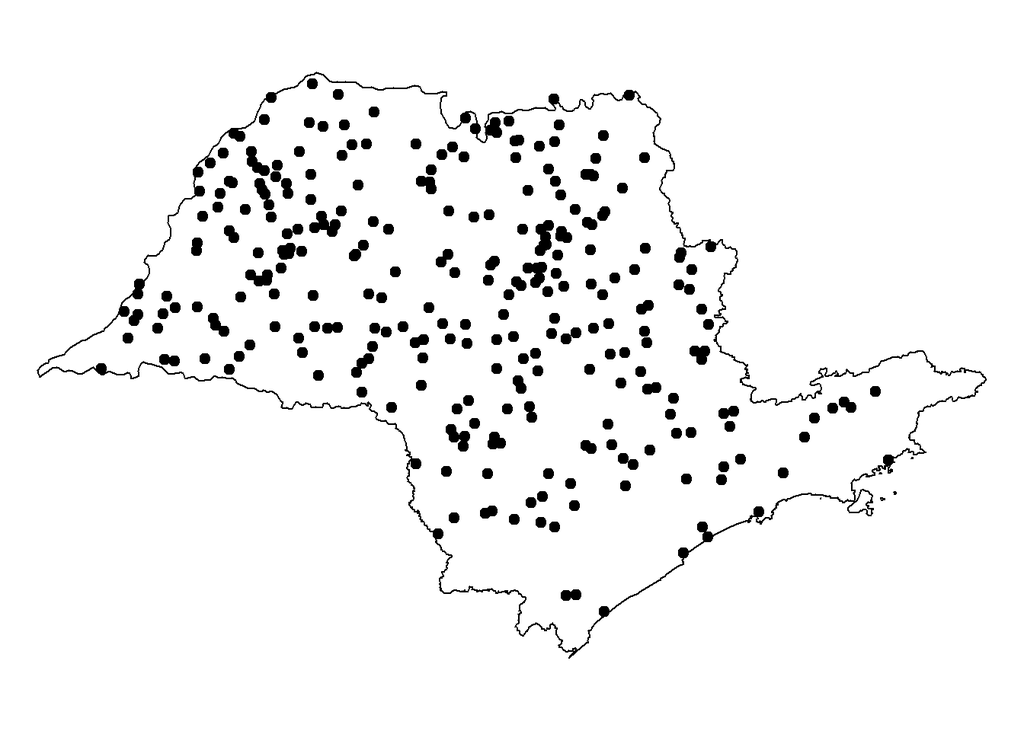

```r
es <- e[e$UF=="SP",]

as <- a[which(a$UF=="SP"),]

par(mar=rep(0,4))
plot(es)
plot(as, pch=19, add=T)
```

Once it is done, we can run the spvoro function to obtain the voronoi. It returns a SpatialPolygonsDataFrame object with the new boundaries computed from the points.

```r
par(mar=rep(0,4))
vo <- spvoro(as,es,ID = "NOME")
```

[output not shown]

```
## deldir 0.1-12
```

[output not shown]

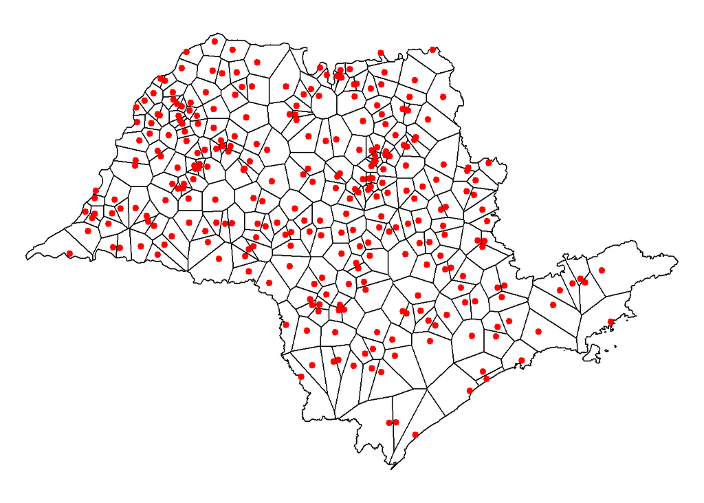

As you can see, the function plotted the new map with the voronoi polygons with the boundaries of the Sao Paulo state and created a new spatial object called vo. Now we can just plot vo again to see what happens.

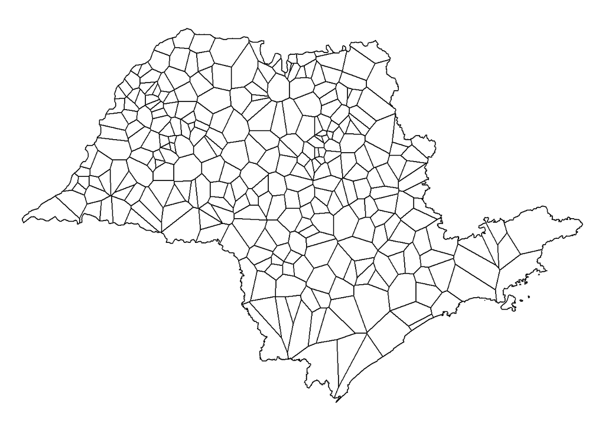

```r
par(mar=rep(0,4))
plot(vo)
```

Now we are able to perform new analyses such as the number of people served by each aerodrome or the demographic density of each of them (since we can determine the area of these polygons). This logic can be applied from coffee shops to hospitals or political party committees.

## Spatial Descriptive measures: mean center and standard distance

Another useful application for spatial analysis is to assess some basic descriptive values for the distribution of events. Where is the mean center of a given social, political or economic phenomenon? what is the level of dispersion or concentration of a given event? Before using more sophisticated techniques, such as kernel density estimators or kriging, it is useful to have some basic description of the location of the center and the size of variation to be dealt with. This can be particularly handy when we compare the same phenomenon in different points in time or according to different groups or strata.

In order to illustrate the functions, we will load the data and compute the mean center and the standard distance for all Brazilian Municipalities. Afterwards, we will plot the mean center and a circle representing the standard distance on the Brazilian States map.

The parameters of the spdesc function are the following:

** spobj -** the SpatialPointsDataFrame to be employed to compute the spatial descriptive statistics.

** w -** the name of the variable on the SpatialPointsDataFrame used to weight cases.

** by -** a vector containing the grouping information employed to separate cases.

```r
## Merges electoral data (br) to the geographical locations of Brazilian municipalities (bl)
br <- br[order(br$year),]
br <- merge(br, bl, by="GEOCODIG_M", all.x=T)
br <- br[! is.na(br$LONG),]

## Converts the new object into a SpatialPointsDataFrame
coordinates(br) <- ~LONG+LAT

### Simple example: Brazilian localities

# Spatial descriptives for the Brazilian localities
bx <- spdesc(bl)

# See the results
bx
```

```
##              coordinates   sp_sd
## 1 (-46.22703, -16.44608) 10.4712
```

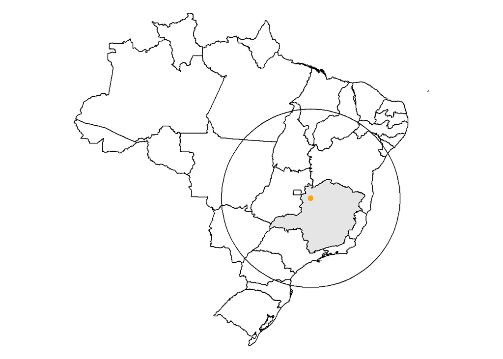

```r
# plot the results
par(mar=rep(0,4))
plot(e)
plot(e[e$UF=="MG",], col="grey90", add=T)
plot(bx, pch=19, col="orange", add=T)

# Draws a circle with a radius corresponding to the standard distance (package plotrix)
draw.circle(coordinates(bx)[,1],coordinates(bx)[,2], bx$sp_sd)
```

This map represents the geographical center of Brazil and the circle the standard distance among municipalities. In itself it tells us little more about what we already know. These statistical procedures make the most when applied to particular phenomena, such electoral politics or demographic changes.

On the other hand, we do not want to know just the differences between parties, but we also are curious about how the geographical pattern of each party changed over time. Therefore, we define the year of election as a grouping variable. This will make the function return a mean center and a standard distance for each election. The code and the results are below:

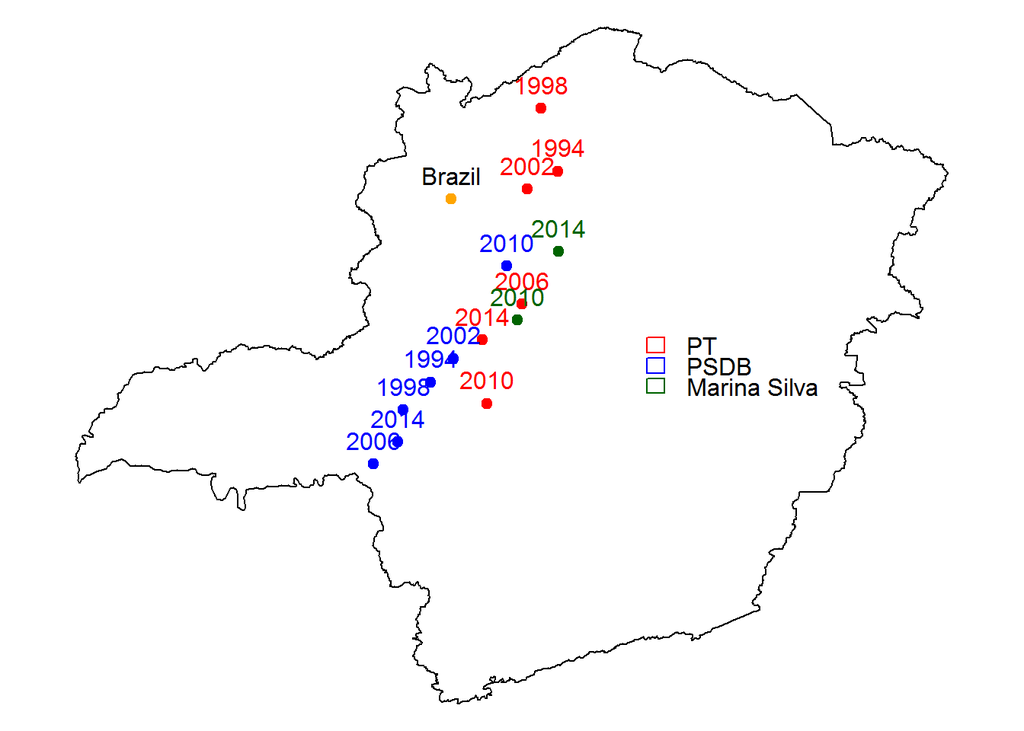

```r
# Separates the data for each major party: PT, PSDB and PSB
pt <- br[br$party==13,]
ps <- br[br$party==45,]
po <- br[br$party==43 & br$year==2010,]
po <- rbind(po, br[br$party==40 & br$year==2014,])


# Compute the spatial descriptives for each party
xt <- spdesc(pt, w = "qt_votes",by = pt$year)
xs <- spdesc(ps, w = "qt_votes",by = ps$year)
xo <- spdesc(po, w = "qt_votes",by = po$year)

# Plot the State of Minas Gerais (where all cases are located)
par(mar=rep(0,4))
plot(e[e$UF=="MG",])

# Adds the centers for each party and year in the map
plot(xt, pch=19, col="red", add=T)
plot(xs, pch=19, col="blue", add=T)
plot(xo, pch=19, col="darkgreen", add=T)

# Adds the years to identify each election
text(coordinates(xt), labels = xt$by, col = "red", pos=3)
text(coordinates(xs), labels = xs$by, col = "blue", pos=3)
text(coordinates(xo), labels = xo$by, col = "darkgreen", pos=3)

# Adds Brazilian mean center
plot(bx, pch=19, col="orange", add=T)
text(coordinates(bx), labels = "Brazil", pos = 3)

# Adds a legend to the map
legend(-44,-18, legend = c("PT","PSDB","Marina Silva"), fill=rep("white",3),
       border = c("red", "blue","darkgreen"), bty="n", y.intersp = 0.7)
```

The resulting map tells us a few things. Firstly, parties differ in terms of their geographical distribution of votes. They do so among themselves and in different elections. The PT vote is more concentrated in the North and Northeastern regions of the countries while the PSDB vote is centered on the Center-South region. Marina Silva performs better in the Southeastern metropolises and capture some of the vote of the PT in the Northeast region. This happens especially in 2014, when she runs for the PSB, a party with deep roots in the Northeastern state of Pernambuco.

For both the PT and the PSDB, we can observe different trends of going north and south. This can be explained by different causes. One of them is the level of national appeal of presidential candidates. For instance, José Serra (PSDB, 2010) was a much more “national” candidate than his colleagues Geraldo Alckimin (PSDB, 2006) or Aécio Neves (PSDB, 2014), much more supported in the Center-South, but with little penetration in the North-Northeast.

The PT vote presents a trend to move south from 1998 on. This is a sign of the nationalization of the vote in the party and the increasing margins of victory obtained by the party until 2010. In 2014, the election was more competitive, with the south massively supporting Aécio Neves. This can be seen in the displacement of the PT center to the north.

This straightforward example shows us the usefulness of these summary statistics. They do not replace deeper and careful analyses, but they allow researchers and users to grasp general trends and changes in patterns that could lead to new hypotheses and explanations.

## Spatial Lagged variable

One of the most employed methods in spatial analysis is the spatial autocorrelation. One step of this analysis is to compute the spatial lagged value for a given variable. In simple terms, it represents the average value of all neighbors of a given area. These values, then, are compared to the original variable in order to compute the spatial association between the original values and the lagged values. The Moran’s I is the most know application of this principle. Nonetheless, the spatial lagged version of a variable can have other applications. In thematic cartography, it smooths the distribution of variables, facilitating the visualization of patterns and regional cluster of values. The function splag computes the spatial lagged variable for both polygons and points, allowing for comparisons and analyses outside the predefined spatial functions or packages. The parameters are:

** spobj - ** spatial object to be used to create the neighborhood matrix.

** val - ** variable containing the original values.

**queen -** defines if the contiguity matrix will employ a queen or rook matrix type. The default value is TRUE.

For point objects, we employ a delayney triangulation (or a natural neighbors) matrix.

The following code returns a new variable (with the same length as val) contaning the lagged values for val.

```r
br <- data.frame(br)
bpt <- br[br$party==13 & br$year==2002, c("GEOCODIG_M","qt_votes","tot_votes","prop_votes")]
ba <- merge(b, bpt, by="GEOCODIG_M", all.x=T )


ba$lag <- splag(spobj = ba, ba$prop_votes, queen = T)
```

[output not shown]

[output not shown]

We can check the results mapping the original values vis-à-vis the lagged version. We will do so for the 2002 vote for Lula (PT) in the Presidential elections. In order to do so, we will create a wrap-up function to map values and avoid repeating code.

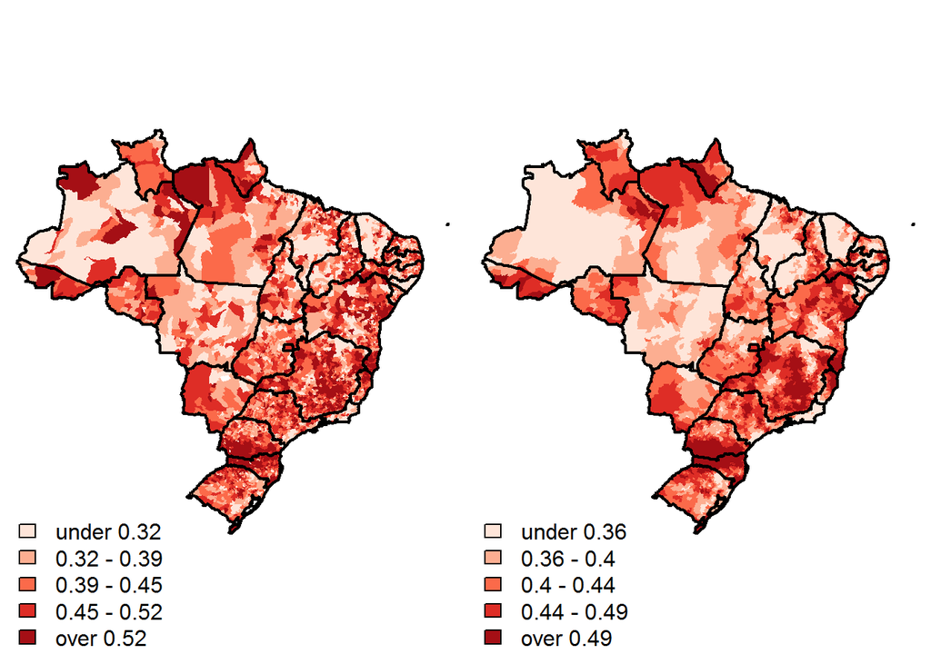

```r
map <- function(spobj, spframe, var){

  require(RColorBrewer)

  col <- brewer.pal(n = 5, "Reds")
  v <- quantile(x = var, probs = seq(0,1,0.2), na.rm = T)
  legs <- leglabs(round(v,2))
  plot(spframe)
  plot(spobj, pch=19, col=col[findInterval(var,v, all.inside = T)], add=T, border="transparent")
  plot(spframe, lwd=2, add=T)
  legend("bottomleft", fill=col, legend = legs, bty="n")

}

# Maps the results side by side
par(mfrow=c(1,2))

par(mar=rep(0,4))

map(ba,e,ba$prop_votes)
map(ba,e,ba$lag)
```

```r
par(mfrow=c(1,1))
```

As we can see, the lagged version of the variable offers a cleaner visualization of the voting patterns for the PT in 2002. It emphasizes those regions where Lula had both better and worse performance, allowing the identification of subtle spatial clusters within a more general and nationalized voting patterns.

## Location Quotient

The location quotient (LQ) represents the proportion of a given phenomenon observed in an area compared to the same proportion in a larger geographical unit. How large is the vote in Party A in region A compared to its performance nationally? How better is the proportion of Party A compared to Party B? In mathematical terms is the ratio between the value of a given variable in region A compared to its value in a larger territorial reference (municipalities from states or regions, regions in countries, countries and the world, etc.). Regions above one present higher values than the average.

If we measure party performance, a LQ in regions above 1.0 would mean that the party was particularly successful in them, compared to other regions. The contrary is also true. Regions with LQ below 1.0 are poor performance regions, places where the party failed to attract votes.

The function has only two parameters:

**var1 -** numeric vector containing the values for the first variable. **var2 -** numeric vector containing the values for the comparison (total population, total number of votes, etc.).

The example below applies the location quotient to determine the regions of concentration of vote of the PSDB abd PSB, as well the performance of PSDB and PSB between themselves.

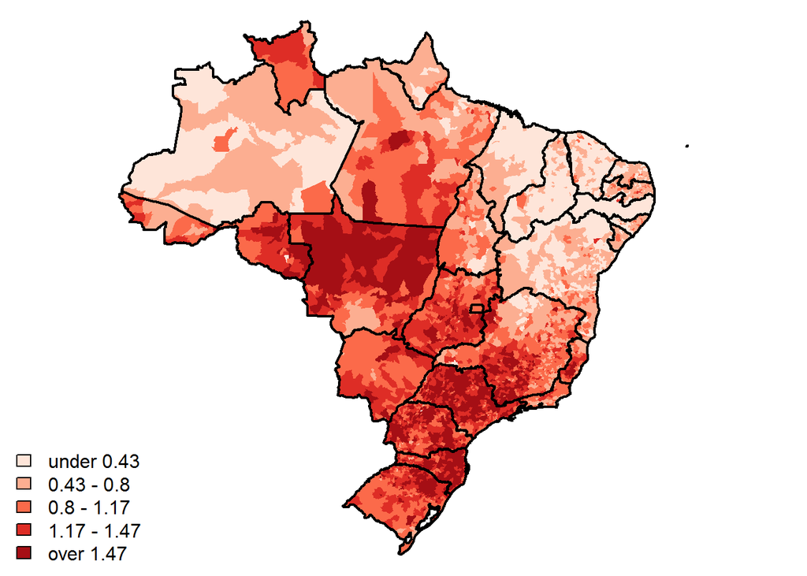

```r
bpa <- br[br$party==45 & br$year==2014, c("GEOCODIG_M","qt_votes","tot_votes")]
bpb <- br[br$party==40 & br$year==2014, c("GEOCODIG_M","qt_votes")]

names(bpa) <- c( "GEOCODIG_M","pa_votes","tot_votes")
names(bpb) <- c( "GEOCODIG_M","pb_votes")

bpa <- merge(bpa, bpb, by="GEOCODIG_M", all.x=T)
ba <- merge(b, bpa, by="GEOCODIG_M", all.x=T )

par(mar=rep(0,4))

# PSDB votes against PSB votes
map(ba,e,lqcalc(ba$pa_votes,ba$tot_votes))
```

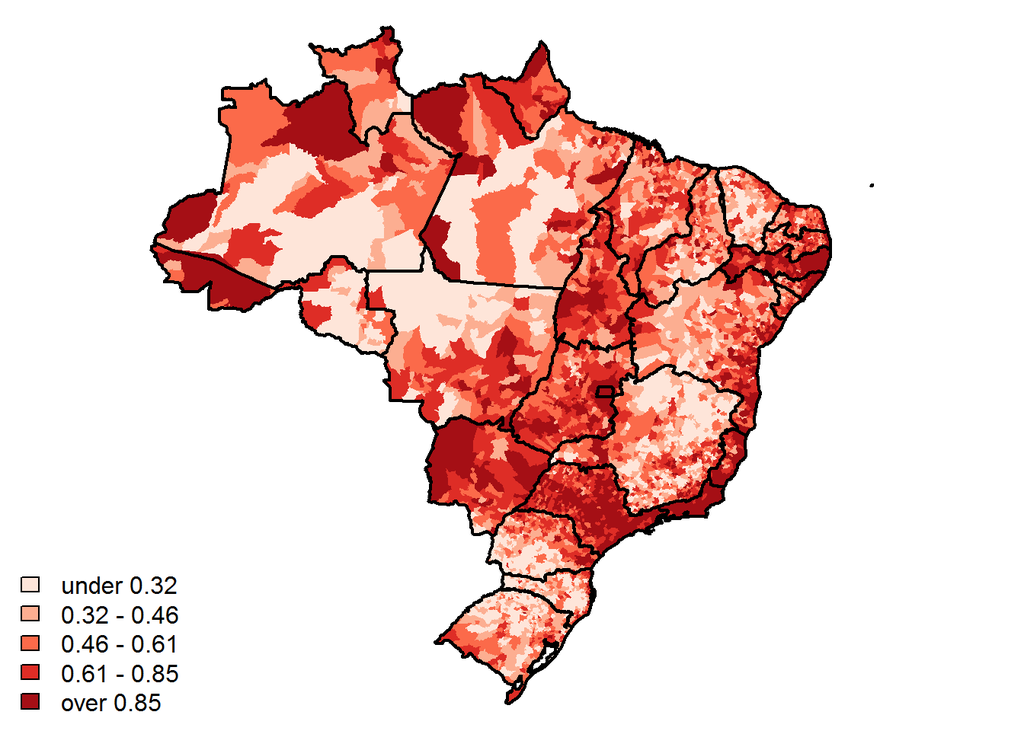

```r
# PSB votes against PSB votes
map(ba,e,lqcalc(ba$pb_votes,ba$tot_votes))
```

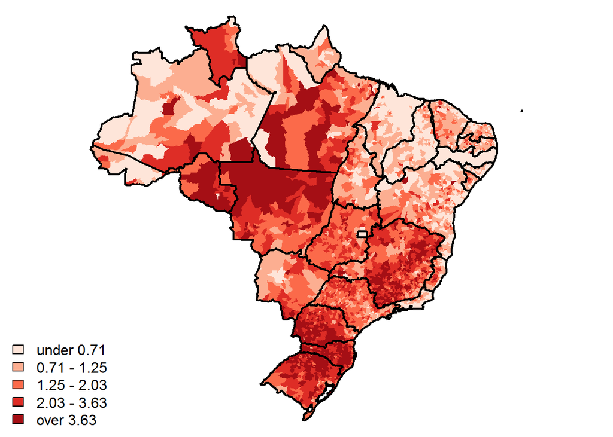

```r
# PSDB votes against the PSB votes
map(ba,e,lqcalc(ba$pa_votes,ba$pb_votes))
```

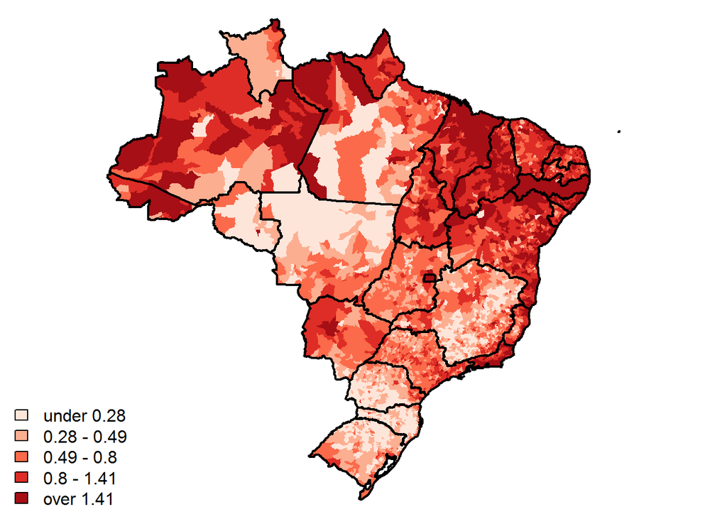

```r
# PSB vs PSDB votes
map(ba,e,lqcalc(ba$pb_votes,ba$pa_votes))
```

The four maps reveal different pictures of the electoral results. The first shows the concentration of the vote in the PSDB on the Center-South regions of Brazil. The second uncovers a more fragmented clustering pattern of the vote in the PSB. This last party had its best performance. In Pernambuco, its traditional stronghold, in Rio de Janeiro, but also in states dominated by the PSDB, such as São Paulo. Although there is a state-level clustering (Acre, Rio de Janeiro, Mato Grosso do Sul, São Paulo, the Federal District, and Pernambuco) the concentration pattern of the PSB is very different from that observed in the PSDB vote.

The third map reveals where PSDB had a better performance compared to the PSB vote. The fourth shows the reverse. This explains why they are the negative of one another. Compared to the PSB, the PSDB is concentrated in the Center-South. Compared to the PSDB, the PSB is concentrated mostly on the North and Northeastern regions of the country.

The usefulness of these maps comes from the fact that they allow comparisons in space of different events, groups or moments in time. If we run the same statistics for two different points in time, we can observe some important changes in spatial patterns. For example, we can compare the PSDB vote in 2014 and 1998 to identify those municipalities where the party performed better (and worse) in 2014:

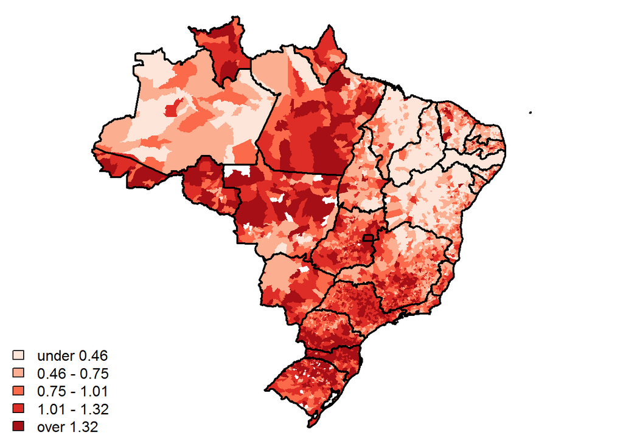

```r
bpa <- br[br$party==45 & br$year==1998, c("GEOCODIG_M","qt_votes","tot_votes")]
bpb <- br[br$party==45 & br$year==2014, c("GEOCODIG_M","qt_votes")]

names(bpa) <- c( "GEOCODIG_M","pa_votes","tot_votes")
names(bpb) <- c( "GEOCODIG_M","pb_votes")

bpa <- merge(bpa, bpb, by="GEOCODIG_M", all.x=T)
ba <- merge(b, bpa, by="GEOCODIG_M", all.x=T )

par(mar=rep(0,4))

# PSDB vote in 2014 compared to PSDB vote in 1998
map(ba,e,lqcalc(ba$pb_votes,ba$pa_votes))
```

The data and the code are available at Github: https://github.com/rodrodr/Spatial_Analysis/